# Analysis of NOAA Storm Data in regards to Population Health and Economic Consequences

Jan Schering

8/5/2020

# Synopsis

This paper is aiming to analyse the data provided by the NOAA Storm Database in regards to the implications of certain events. The goal is to find out which events are having the most dire consequences on society, based on two parameters.

The first parameter is harm caused in regards to human health/population health. The paper seeks to address, which events cause the most population harm across the United States.

The second parameter is economic consequences. Within the analysis it will be explored which events cause the greatest measurable economic consequences.

In the processing section the raw data is subset to only include relevant information and the events in the EVTYPE column are mapped to official NOAA events. THe data then gets grouped by the official event types and the sum of casualties and damages for each event calculated. The calculation shows that the most critical event for population health is Tornadoes, while the most critical event for economy is floods.

# Introduction

The analysis in this paper is based on the NOAA Storm Data database. The specific data used can be downloaded under https://d396qusza40orc.cloudfront.net/repdata%2Fdata%2FStormData.csv.bz2

The data used contains recordings of storm events between 1950 and 2011 in the USA. Each row in the data represents the observation of one event. It is important to note that a storm can consist of multiple events.

## Goal

The goal of the analysis is to rank the most critical weather/storm events in the USA under two facets: Implication for population health and implication on economy.

In order to do this, the raw data gets processed in a way that allows for comparisons in the numbers to be drawn. Once the processing is done, the processed subset of the raw data is used to produce histograms of the population health and economy implications of the events.

The events can then be ranked in order of most- to least critical.

# Data Processing

This section provides an in-depth description of the Data Processing done for the analysis. The steps taken will be explained and reasoned.

## First Steps

As the first step, the data is loaded in and the structure of the data set is observed using the **names()** function. The data is read directly from the compressed source file:

```r
  #the data is loaded straight from the compressed source file
  data <- read.csv("./repdata_data_StormData.csv.bz2", stringsAsFactors = FALSE)

  # prints the column names of the data set
  print(names(data))
```

```
##  [1] "STATE__"    "BGN_DATE"   "BGN_TIME"   "TIME_ZONE"  "COUNTY"
##  [6] "COUNTYNAME" "STATE"      "EVTYPE"     "BGN_RANGE"  "BGN_AZI"
## [11] "BGN_LOCATI" "END_DATE"   "END_TIME"   "COUNTY_END" "COUNTYENDN"
## [16] "END_RANGE"  "END_AZI"    "END_LOCATI" "LENGTH"     "WIDTH"
## [21] "F"          "MAG"        "FATALITIES" "INJURIES"   "PROPDMG"
## [26] "PROPDMGEXP" "CROPDMG"    "CROPDMGEXP" "WFO"        "STATEOFFIC"
## [31] "ZONENAMES"  "LATITUDE"   "LONGITUDE"  "LATITUDE_E" "LONGITUDE_"
## [36] "REMARKS"    "REFNUM"
```

There are 37 columns in the data set.

Not all of them, however, will be needed for the analysis. In order to make the data set easier to work with, the next step is to subset the relevant categories. For the question this paper seeks to explore these columns are:

- BGN_DATE
- END_DATE
- EVTYPE
- FATALITIES
- INJURIES
- PROPDMG
- PROPDMGEXP
- CROPDMG
- CROPDMGEXP
- REMARKS

To achieve this structure a new data set named “relevant_data” is created as a subset of the source data set:

```r
  # getting a subset of the dataset by explicitly stating which rows should be included
  relevant_data <- data[, c("BGN_DATE", "END_DATE", "EVTYPE", "FATALITIES", "INJURIES", "PROPDMG", "PROPDMGEXP", "CROPDMG", "CROPDMGEXP", "REMARKS")]

  # after the subsetting, str gives the structure of the subset
  print(str(relevant_data))
```

```
## 'data.frame':    902297 obs. of  10 variables:
##  $ BGN_DATE  : chr  "4/18/1950 0:00:00" "4/18/1950 0:00:00" "2/20/1951 0:00:00" "6/8/1951 0:00:00" ...
##  $ END_DATE  : chr  "" "" "" "" ...
##  $ EVTYPE    : chr  "TORNADO" "TORNADO" "TORNADO" "TORNADO" ...
##  $ FATALITIES: num  0 0 0 0 0 0 0 0 1 0 ...
##  $ INJURIES  : num  15 0 2 2 2 6 1 0 14 0 ...
##  $ PROPDMG   : num  25 2.5 25 2.5 2.5 2.5 2.5 2.5 25 25 ...
##  $ PROPDMGEXP: chr  "K" "K" "K" "K" ...
##  $ CROPDMG   : num  0 0 0 0 0 0 0 0 0 0 ...
##  $ CROPDMGEXP: chr  "" "" "" "" ...
##  $ REMARKS   : chr  "" "" "" "" ...
## NULL
```

The resulting Data Frame contains observations of 10 variables

## Cleaning, Combining and Converting Information

The relevant subset can be further reduced.

The columns “PROPDMG” and “CROPDMG” both have a related column “…EXP”. This column is indicating the exponent of 10, by which to multiply the DMG value. The next step is to use the EXP columns to calculate the actual damage values. Taking a look at the values the columns can take on, they appear to be more noisy than expected:

```r
  # with the table function its possible to see how the CROP/PROP EXP columns are made up

  print(table(relevant_data$PROPDMGEXP))
```

```
##
##             -      ?      +      0      1      2      3      4      5      6
## 465934      1      8      5    216     25     13      4      4     28      4
##      7      8      B      h      H      K      m      M
##      5      1     40      1      6 424665      7  11330
```

```r
  print(table(relevant_data$CROPDMGEXP))
```

```
##
##             ?      0      2      B      k      K      m      M
## 618413      7     19      1      9     21 281832      1   1994
```

As shown in the table, the columns can possibly take values between 0-8, as well as “?”, “+” and the letters B, h, H, k, K, m, M. The letters stand for

- b|Billion
- m|Million
- h|Hundred

while the numbers are giving the exponent of 10 to multiply the value with. The “?” as well as the “+” will be assumed to be faulty entries in the following and thus valued as 0. With this in mind, the EXP columns can be used to calculate the complete values in the DMG columns:

```r
  # this helper function takes a numeric value + an exponent indicator from the EXP columns and returns the numeric multiplied with
  # 10 to the power of the exponent
  mapExponentsToValues <- function(x, y) {

    x <- as.numeric(x)

    if(y == "h" | y == "H") {
      return (x * ( 10 ^ 2  ))
    } else if (y == "k" | y == "K") {
      return( x * (10 ^ 3)  )
    } else if(y == "M" | y == "m") {
      return( x * (10 ^ 6)  )
    } else if(y == "b" | y == "B") {
      return( x * ( 10 ^ 9 )  )
    } else if(!is.na(as.numeric(y))) {
      return( x * (10 ^ as.numeric(y))  )
    } else {
      return(0)
    }
  }

  # the real values of both CROP and PROP damae are calculated with the helper function
  relevant_data$PROPDMG <- mapply(mapExponentsToValues, relevant_data$PROPDMG, relevant_data$PROPDMGEXP)

  relevant_data$CROPDMG <- mapply(mapExponentsToValues, relevant_data$CROPDMG, relevant_data$CROPDMGEXP)

  # the data set can be subset again after the calculation as the exponent columns are not needed anymore
  relevant_data <- relevant_data[ , c("BGN_DATE", "END_DATE", "EVTYPE", "FATALITIES", "INJURIES", "PROPDMG", "CROPDMG", "REMARKS")]

  print(str(relevant_data))
```

```
## 'data.frame':    902297 obs. of  8 variables:
##  $ BGN_DATE  : chr  "4/18/1950 0:00:00" "4/18/1950 0:00:00" "2/20/1951 0:00:00" "6/8/1951 0:00:00" ...
##  $ END_DATE  : chr  "" "" "" "" ...
##  $ EVTYPE    : chr  "TORNADO" "TORNADO" "TORNADO" "TORNADO" ...
##  $ FATALITIES: num  0 0 0 0 0 0 0 0 1 0 ...
##  $ INJURIES  : num  15 0 2 2 2 6 1 0 14 0 ...
##  $ PROPDMG   : num  25000 2500 25000 2500 2500 2500 2500 2500 25000 25000 ...
##  $ CROPDMG   : num  0 0 0 0 0 0 0 0 0 0 ...
##  $ REMARKS   : chr  "" "" "" "" ...
## NULL
```

The combination leaves 8 relevant columns in the data frame.

## Mapping the events in the set to the official NOAA event types

Next, The events listed under “EVTYPE” have to be mapped to the official NOAA event types to allow for comparison.

In this analysis the mapping is done with the “amatch()” function, distributed with the stringdist R Package. The conversion is done with the following:

```r
  # the stringdist package provides fuctions to get and compare distances between strings
  library(stringdist)

  # to map the events in the column to the official events, a vector with all official events is created
  official_events <- c("Astronomical Low Tide","Avalanche","Blizzard","Coastal Flood","Cold/Wind Chill","Debris Flow","Dense Fog","Dense Smoke","Drought","Dust Devil","Dust Storm","Excessive Heat","Extreme Cold/Wind Chill","Flash Flood","Flood","Freezing Fog","Frost/Freeze","Funnel Cloud","Hail","Heat","Heavy Rain","Heavy Snow","High Surf","High Wind","Hurricane/Typhoon","Ice Storm","Lakeshore Flood","Lake-Effect Snow","Lightning","Marine Hail","Marine High Wind","Marine Strong Wind","Marine Thunderstorm Wind","Rip Current","Seiche","Sleet","Storm Tide","Strong Wind","Thunderstorm Wind","Tornado","Tropical Depression","Tropical Storm","Tsunami","Volcanic Ash","Waterspout","Wildfire","Winter Storm","Winter Weather")

  # the official events and the ones n the recordings get set to lowercase
  official_events <- tolower(official_events)
  relevant_data$EVTYPE <- tolower(relevant_data$EVTYPE)

  # amatch gets called on every row in the  data set. The result is used to get an official event from the vector, which then gets set
  # as a value in the new column EVTYPE_official in the data set
  relevant_data$EVTYPE_official <- official_events[amatch(relevant_data$EVTYPE, official_events, method="lv",  maxDist=20)]
```

To check the result of the mapping, the column will be shown as a table. Additionally the amount of unique variables in the column is shown:

```r
  print(table(relevant_data$EVTYPE_official))
```

```
##
##    astronomical low tide                avalanche                 blizzard
##                      279                      421                     2727
##            coastal flood          cold/wind chill              debris flow
##                     4463                      644                       19
##                dense fog              dense smoke                  drought
##                     1368                       37                     2730
##               dust devil               dust storm           excessive heat
##                      158                      459                     1780
##  extreme cold/wind chill              flash flood                    flood
##                     1240                    56314                    27256
##             freezing fog             frost/freeze             funnel cloud
##                      408                     1368                     7598
##                     hail                     heat               heavy rain
##                   288796                     1146                    12089
##               heavy snow                high surf                high wind
##                    16092                     1042                   241897
##        hurricane/typhoon                ice storm         lake-effect snow
##                      113                     2081                      663
##          lakeshore flood                lightning              marine hail
##                       69                    15942                     1566
##         marine high wind       marine strong wind marine thunderstorm wind
##                     6320                       56                     5865
##              rip current                   seiche                    sleet
##                      778                      283                      173
##               storm tide              strong wind        thunderstorm wind
##                      464                     3832                   103732
##                  tornado      tropical depression           tropical storm
##                    60697                       66                      709
##                  tsunami             volcanic ash               waterspout
##                       21                       29                     3885
##                 wildfire             winter storm           winter weather
##                     4894                    11541                     8186
```

```r
  print(length(table(relevant_data$EVTYPE_official)))
```

```
## [1] 48
```

The Column now has been mapped to the 48 official events, as indicated by there being 48 unique values in the column after the mapping.

# Exploratory Analysis

In this section the tidied data set is used to find answers for the two overarching themes of the analysis: Population Health and Economy. For this, the tidied data will be further subset to filter out irrelevant observations for the respective question. Afterwards the relevant observations will be used to calculate key values and create figures to visualize the answers.

## Exploring Implications on Population Health

First, the events relevant to population health will be explored. For this the relevant observations will be filtered and the key figures calculated.

### Filtering out observations relevant to population health

Population health consequences are measured in 2 categories in the data set: Fatalities and Injuries. This means, that in order to analyze the damages, it would be recommended to only work with the observations, which actually include a value for either the Fatalities or Injuries. The relevant observations are filtered out and stored in a subset:

```r
  # the data set is subset to only include observations that have a value higher than 0 in the INJURIES or the FATALITIES
  population_critical_observations <- relevant_data[relevant_data$FATALITIES > 0 | relevant_data$INJURIES > 0,]
```

The subset with the observations relevant to population health contains 21929 observations.

### Calculating key figures in regards to population health

Now that the irrelevant observations have been filtered out, The total weighted casualties caused can be calculated in general and in respect to the types of events.

In this analysis, fatalities will be weighted higher than injuries by a factor of 2. First, the total weighted casualties without respect to event are calculated. The highest observation will be shown with EVTYPE_official, BGN_DATE, END_DATE, weighted_casualties:

```r
  # a new column "weighted_casualties" in the data set is created. The column gets filled with the weighted sum of INJURIES and
  # FATALITIES of the respective rows
  population_critical_observations$weighted_casualties <- population_critical_observations$INJURIES + 2 *  population_critical_observations$FATALITIES

  # printing out the event with the max casualty
print(population_critical_observations[population_critical_observations$weighted_casualties == max(population_critical_observations$weighted_casualties), c("EVTYPE_official", "BGN_DATE", "END_DATE", "weighted_casualties")])
```

```
##        EVTYPE_official          BGN_DATE END_DATE weighted_casualties
## 157885         tornado 4/10/1979 0:00:00                         1784
```

Additionally to this, the observations will be grouped by event and then the sums of weighted casualties taken. This data frame can then be used to rank the events according to the total casualties caused from start of observation until 2011:

```r
  #package for grouping
  library(dplyr)
  # first the data is grouped by event, then the sum is taken for each group
  event_casualty_sums <- population_critical_observations %>% group_by(EVTYPE_official) %>% summarize_at("weighted_casualties", sum)

  #Order the result
  event_casualty_sums <- event_casualty_sums[order(-event_casualty_sums$weighted_casualties),]

  # after ordering the groups by their sum of casualties, here the top 10 events are printed
  print( head(event_casualty_sums , n = 10 ) )
```

```
## # A tibble: 10 x 2
##    EVTYPE_official   weighted_casualties
##    <chr>                           <dbl>
##  1 tornado                        102630
##  2 excessive heat                  10743
##  3 high wind                       10094
##  4 flood                            9141
##  5 lightning                        6869
##  6 heat                             4765
##  7 flash flood                      3887
##  8 thunderstorm wind                2921
##  9 ice storm                        2214
## 10 wildfire                         1952
```

## Exploring Implications on Economy

Economic consequences are measured in two factors in the data set: CROP_DMG and PROP_DMG, meaning the amount of monetary damage to crops and the amount of monetary damage caused to properties as a result of an event.

### Getting the Economy-Damage-relevant observations

Analogous to the casualties, it makes sense to focus the analysis on only the observations that contain damage observed. The observations without any damage can be filtered out:

```r
  # subsetting the data set to only include the observations with CROP or PROP damage higher than 0
  economy_related_observations <- relevant_data[relevant_data$CROPDMG > 0 | relevant_data$PROPDMG > 0,]
```

### Calculating Key figures for the economic implications

To better explore the consequences, it will be useful to combine the two into a economic_damage field. Unlike the casualties for the population, this combination does not have to be weighted, as there is no clear argument for either to be more severe. After calculation the singular event with the hghest economic damage will be shown.

```r
  # in the subset, a new column "economic_damage" is created which contains the sum of the crop and the prop damage
  economy_related_observations$economic_damage <- economy_related_observations$CROPDMG + economy_related_observations$PROPDMG

  # Print out the observation with the highest economic damage
  print(economy_related_observations[economy_related_observations$economic_damage == max(economy_related_observations$economic_damage), c("EVTYPE_official", "BGN_DATE", "END_DATE", "economic_damage")])
```

```
##        EVTYPE_official         BGN_DATE         END_DATE economic_damage
## 605953           flood 1/1/2006 0:00:00 1/1/2006 0:00:00    115032500000
```

The result shows that the event with the highest economic damage was a flood on the 1st of January 2006, which caused an economic_damage of 115032500000 or about 115 billion dollars.

The observations will be further grouped into their respective events, calculating the sum of all damages for each event. After the calculation, the events can be ranked according to their total_economic_damages values.

```r
  # first the subset is grouped by the EVTYPE_official column, afterwards for each group the sum is calculated
  total_economic_damages <- economy_related_observations %>% group_by(EVTYPE_official) %>% summarize_at("economic_damage", sum)

  #Order the result
  total_economic_damages <- total_economic_damages[order(-total_economic_damages$economic_damage),]

  # print the 10 events with the highest damages in order
  print( head(total_economic_damages , n = 10 ) )
```

```
## # A tibble: 10 x 2
##    EVTYPE_official   economic_damage
##    <chr>                       <dbl>
##  1 flood               151264992300
##  2 hurricane/typhoon    75551243800
##  3 tornado              57367217484.
##  4 storm tide           47965739050
##  5 flash flood          29543962628.
##  6 hail                 18768639476.
##  7 drought              15025751600
##  8 seiche               14625474310
##  9 high wind            11727483535
## 10 wildfire              9240155130
```

# Results

After thorough exploration of the data in regards to the questions at hand, this chapter concludes the analysis by looking back on the goals/questions and summarizing the results.

### Visualizing and interpreting the top 10 most critical Events in regards to economic damages

The table shows the 10 events with the highest total economic damage caused since the start of the recording. At the 1st place, floods have caused damages estimated around 150 Billion Dollars. This is almost double the amount of the second place, where hurricanes/typhoons have caused a total of 75.5 Billion Dollars. The rest of the top ranges more closely down to 9.2 Billion dollars for the 10th most critical event, “wildfires”

To further illustrate the data, a barplot with the total damages is drawn.

[figure not shown]

```r
  top_ten <- head(total_economic_damages , n = 10 )

  #adjust the margins of the device
  par(mai=c(1,4,1,1))

  bp <- with(top_ten, barplot(economic_damage, horiz = TRUE, names.arg = EVTYPE_official, las = 1, xlim = c(9000000000, 160000000000), main = "Top 10 Total Economic Damages grouped by Event", xlab = "Amount of Damage in Dollars" ) )
```

### Interpreting and visualizing the top 10 most critical events for population health

To further illustrate the impact of each event, the next step is to draw a barplot of the weighted casualties measured by event.

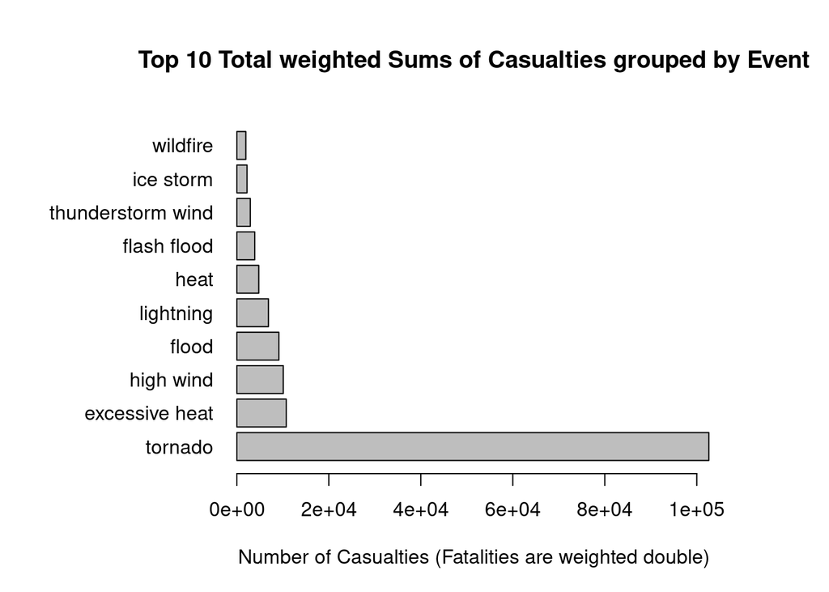

```r
  top_ten <- head(event_casualty_sums , n = 10 )

  #adjust the margins of the device
  par(mai=c(1,2,1,1))

  bp <- with(top_ten, barplot(weighted_casualties, horiz = TRUE, names.arg = EVTYPE_official, las = 1, xlim = c(0, 103000), main = "Top 10 Total weighted Sums of Casualties grouped by Event", xlab = "Number of Casualties (Fatalities are weighted double)" ) )
```